# Dr. Marron’s Suggestions

# Cleaning and organizing the Dataset

```r
library(readr)
CTDC <- read_csv("../Datasets/CTDC.csv")[-c(1)]
head(CTDC)
```

| yearOfRegistration | Datasource | gender | ageBroad | majorityStatus | majorityStatusAtExploit | majorityEntry | citizenship | meansOfControlDebtBondage | meansOfControlTakesEarnings | meansOfControlRestrictsFinancialAccess | meansOfControlThreats | meansOfControlPsychologicalAbuse | meansOfControlPhysicalAbuse | meansOfControlSexualAbuse | meansOfControlFalsePromises | meansOfControlPsychoactiveSubstances | meansOfControlRestrictsMovement | meansOfControlRestrictsMedicalCare | meansOfControlExcessiveWorkingHours | meansOfControlUsesChildren | meansOfControlThreatOfLawEnforcement | meansOfControlWithholdsNecessities | meansOfControlWithholdsDocuments | meansOfControlOther | meansOfControlNotSpecified | meansOfControlConcatenated | isForcedLabour | isSexualExploit | isOtherExploit | … |
| --- | --- | --- | --- | --- | --- | --- | --- | --- | --- | --- | --- | --- | --- | --- | --- | --- | --- | --- | --- | --- | --- | --- | --- | --- | --- | --- | --- | --- | --- | --- |
| 2002 | Case Management | Female | 18--20 | Adult | NA | NA | CO | NA | NA | NA | NA | NA | NA | NA | NA | NA | NA | NA | NA | NA | NA | NA | NA | NA | 1 | NA | 0 | 1 | 0 | … |
| 2002 | Case Management | Female | 18--20 | Adult | NA | NA | CO | NA | NA | NA | NA | NA | NA | NA | NA | NA | NA | NA | NA | NA | NA | NA | NA | NA | 1 | NA | 0 | 1 | 0 | … |
| 2002 | Case Management | Female | 18--20 | Adult | NA | NA | CO | NA | NA | NA | NA | NA | NA | NA | NA | NA | NA | NA | NA | NA | NA | NA | NA | NA | 1 | NA | 0 | 1 | 0 | … |
| 2002 | Case Management | Female | 18--20 | Adult | NA | NA | CO | NA | NA | NA | NA | NA | NA | NA | NA | NA | NA | NA | NA | NA | NA | NA | NA | NA | 1 | NA | 0 | 1 | 0 | … |
| 2002 | Case Management | Female | 18--20 | Adult | NA | NA | CO | NA | NA | NA | NA | NA | NA | NA | NA | NA | NA | NA | NA | NA | NA | NA | NA | NA | 1 | NA | 0 | 1 | 0 | … |
| 2002 | Case Management | Female | 18--20 | Adult | NA | NA | CO | NA | NA | NA | NA | NA | NA | NA | NA | NA | NA | NA | NA | NA | NA | NA | NA | NA | 1 | NA | 0 | 1 | 0 | … |

Remove Character variables that concatenate the sub-type variables

```r
CTDC2 = CTDC[-c(27,36,50,55,57)]
#head(CTDC2)
table(complete.cases(CTDC2))
```

```
FALSE  TRUE
97713    37
```

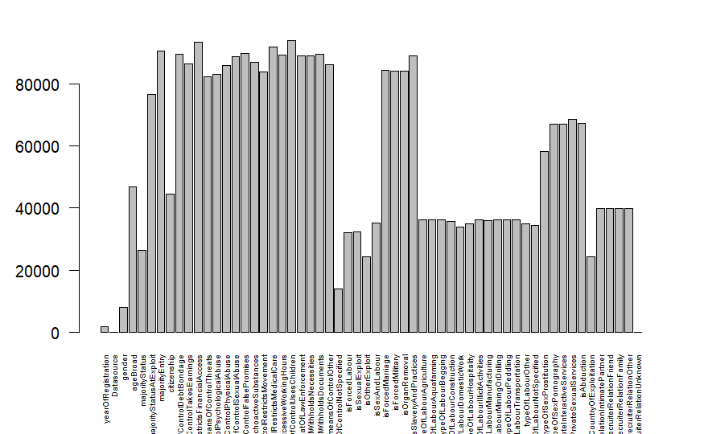

```r
barplot(colSums(is.na(CTDC2)),las=2, cex.names=.5)
```

```r
table(complete.cases(CTDC2))
```

```
FALSE  TRUE
97713    37
```

```r
CTDC3 = CTDC2[-c(5,6,7)]
table(complete.cases(CTDC3))
```

```
FALSE  TRUE
96952   798
```

After removing them, we have 798 complete cases.

**Now replace country with stage in DTM**

Turn alpha 2 code into alpha 3 since alpha-3 is used in the DTM dataset

Create dataframe with Alpha-2 codes,and DTM stage

```r
codes = read_csv("../Datasets/CountryCodes.csv")
dtm = read_csv("../Datasets/Countries_Data2.0.csv")[c(2,14)]
codes
```

| English short name lower case | Alpha-2 code | Alpha-3 code | Numeric code | ISO 3166-2 |
| --- | --- | --- | --- | --- |
| Afghanistan | AF | AFG | 004 | ISO 3166-2:AF |
| Åland Islands | AX | ALA | 248 | ISO 3166-2:AX |
| Albania | AL | ALB | 008 | ISO 3166-2:AL |
| Algeria | DZ | DZA | 012 | ISO 3166-2:DZ |
| American Samoa | AS | ASM | 016 | ISO 3166-2:AS |
| Andorra | AD | AND | 020 | ISO 3166-2:AD |
| Angola | AO | AGO | 024 | ISO 3166-2:AO |
| Anguilla | AI | AIA | 660 | ISO 3166-2:AI |
| Antarctica | AQ | ATA | 010 | ISO 3166-2:AQ |
| Antigua and Barbuda | AG | ATG | 028 | ISO 3166-2:AG |

[output cut: 236 more lines]

```r
###### left join in R using merge() function
df = merge(x=codes,y=dtm, by.x="Alpha-3 code", by.y = "Code", all.x=TRUE)
df2 = df[c(3,6)]
```

Add column in CTDC with DTM stage for “countryOfExploitation”

```r
df3 = merge(x=CTDC3,y=df2, by.x="CountryOfExploitation", by.y = "Alpha-2 code", all.x=TRUE)


#rename DTM_Stage to exploitDTM
names(df3)[ncol(df3)] = "exploitDTM"

#move columns
CTDC4 = df3[c(2:6,1,ncol(df3),8:ncol(df3)-1)]
```

Add column in CTDC with DTM stage for “citizenship”

```r
df5 = merge(x=CTDC4,y=df2, by.x="citizenship", by.y = "Alpha-2 code", all.x=TRUE)

#rename DTM_Stage to citizenshipDTM
names(df5)[ncol(df5)] = "citizenshipDTM"
#move columns
df6 = df5[c(2:7,1,ncol(df5),9:ncol(df3)-1)]
```

Now we have a dataset that contains all the information we need.

```r
traffic = df6
#head(traffic)
#write.csv(traffic, "CTDCSimple1.csv")
```

# Exploratory Data analysis

## Simple Plots

Each bar represents a different stage in Demographic transition for the citizenship or exploitation country of a trafficking victim (citizenshipDTM and exploitDTm respectivley). The width of the bar represents proportionally, how many entries in the data set have that for the exploitation or citizenship country for that entry. Finally, the dark area for each bar shows what proportion of the entries with that stage, have the attribute of the left axis label.

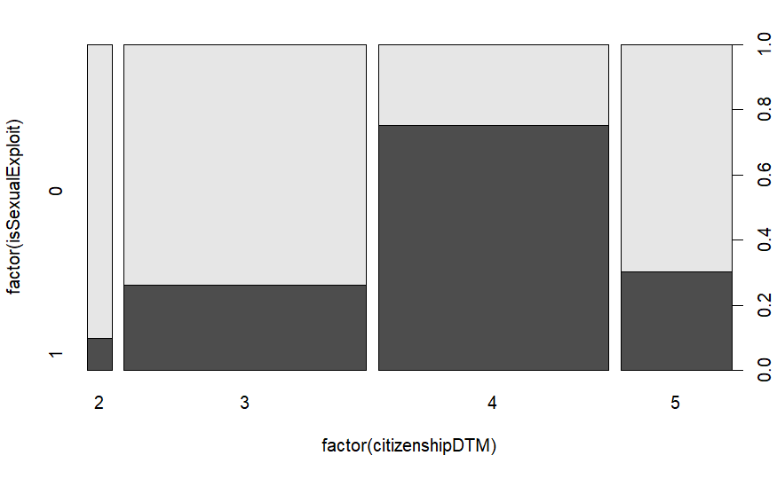

```r
plot(factor(isSexualExploit)~factor(citizenshipDTM), data = traffic)
```

We can tell from this plot for example, that stage 2 countries have the lowest proportion of sexual exploits in our dataset, and stage 4 countries have the highest proportion. By looking at these plots, we can roughly determine visually which aspects of human trafficking have the greatest correlation with DTM stage.

Unfortunately a simple numerical correlation would not work because, as in the case of sexual exploits, we see that there is no linear correlation, but it does appear to be true that sexual exploits become more likely as a country moves from stage 2 to 3, and 3 to 4, but less likely from 4 to 5.

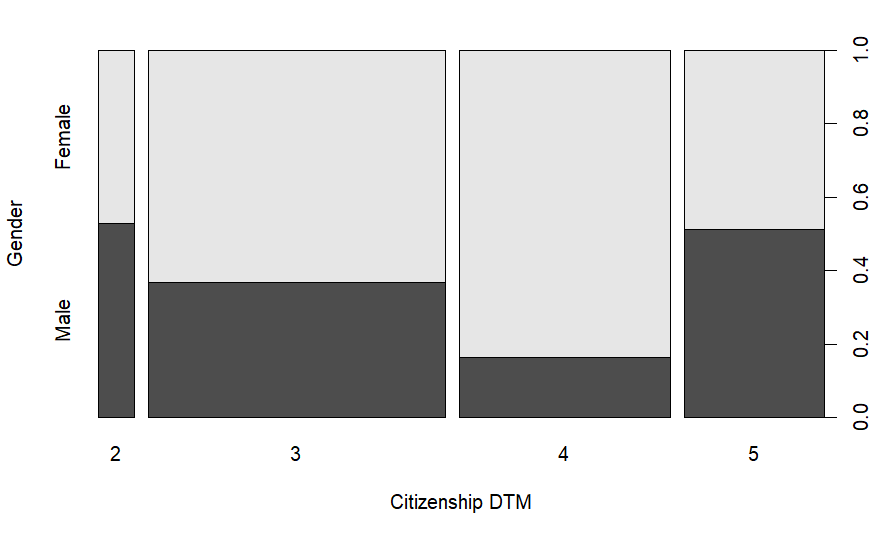

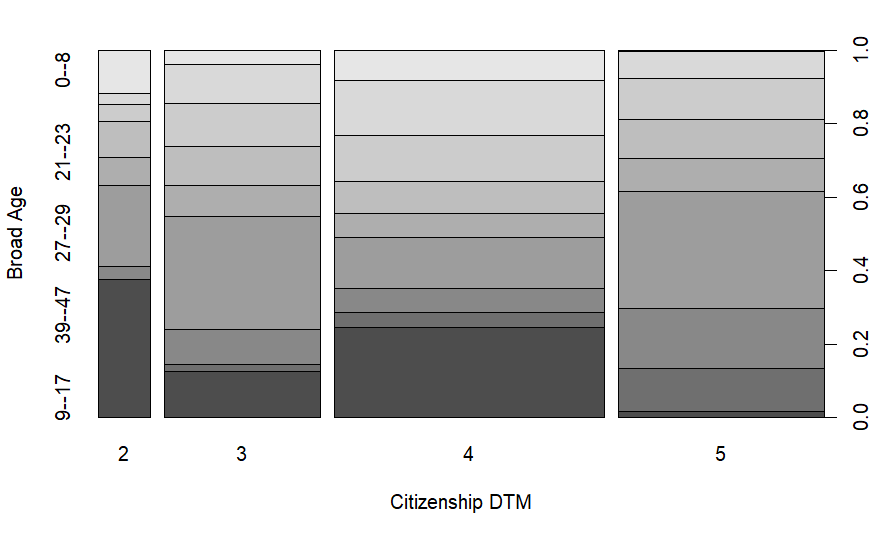

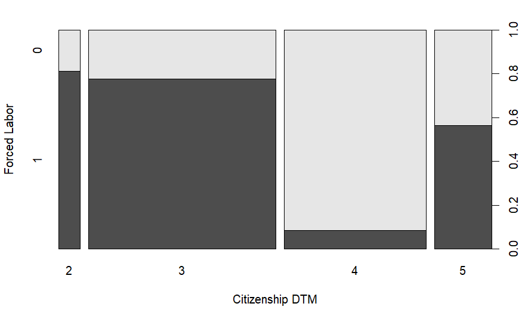

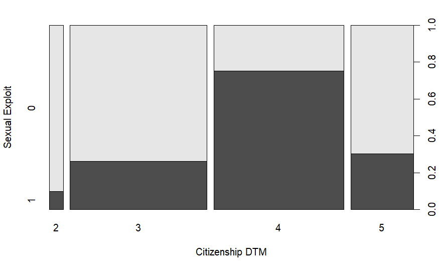

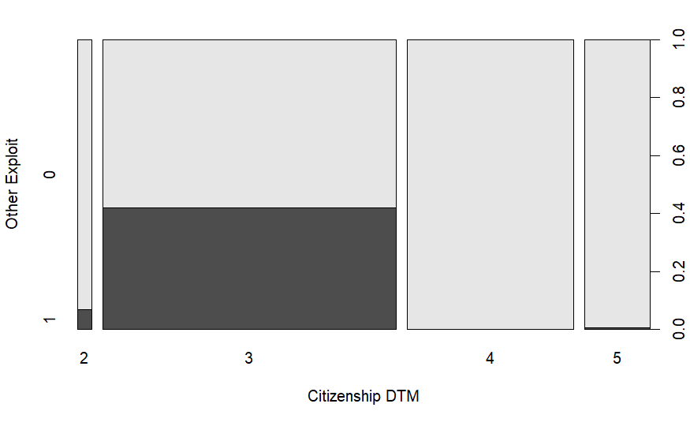

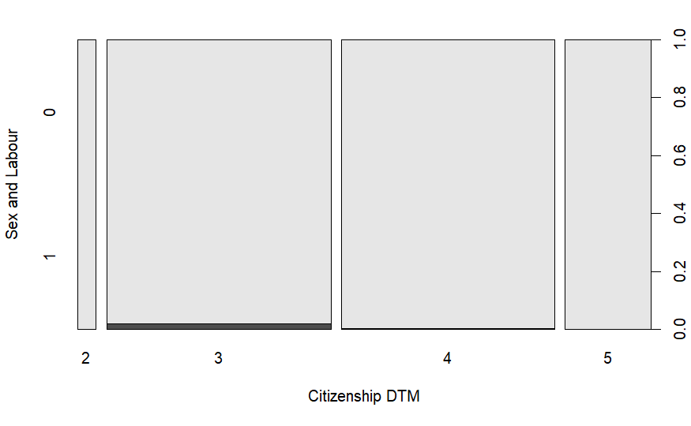

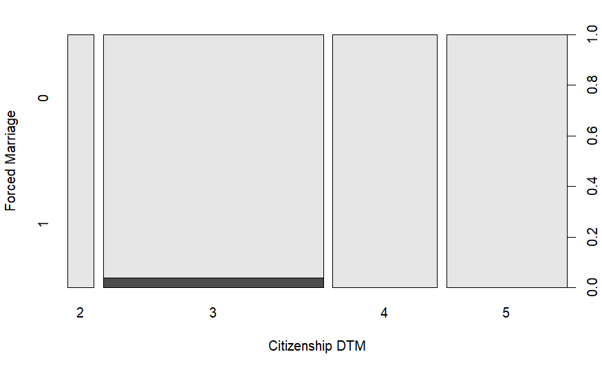

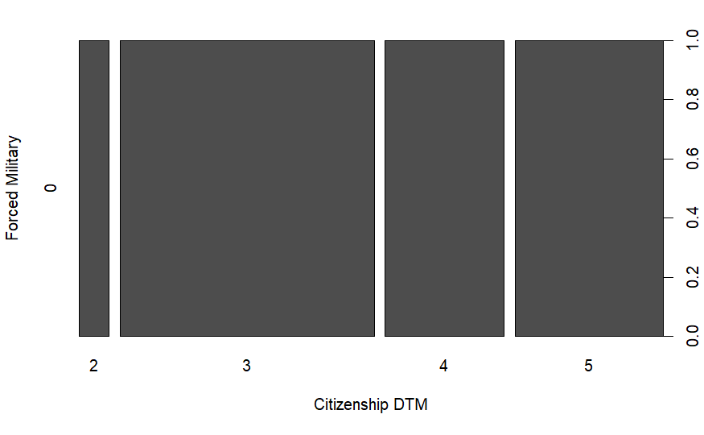

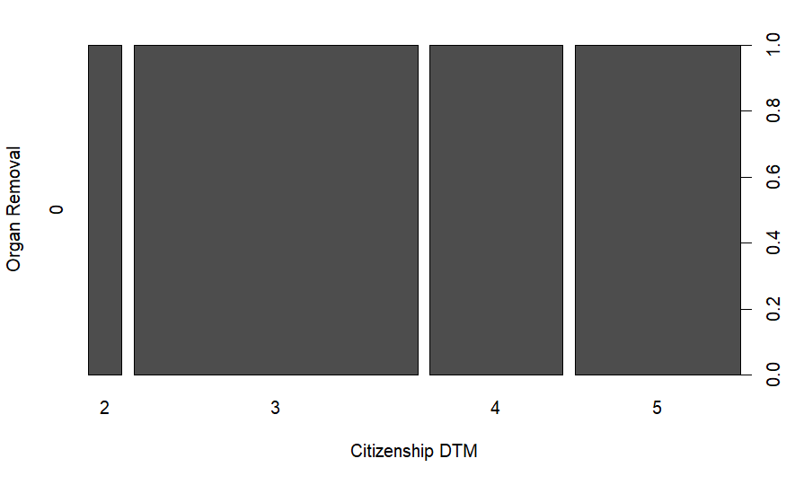

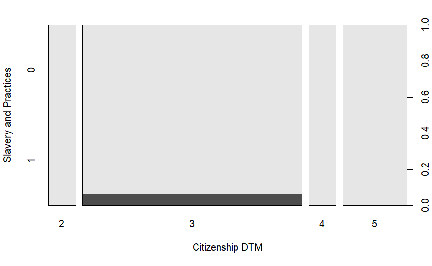

Looking at the distribution of ages in each DTM stage, there appears to potentially be an interaction between Citizenship DTM and age.

## Repeat for ExploitDTM

Here we repeat the same process for Exploitation Country DTM

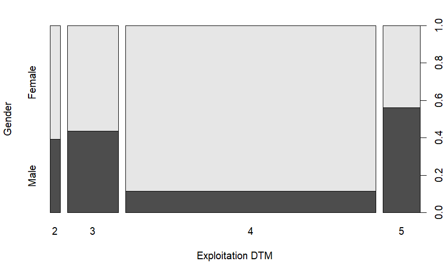

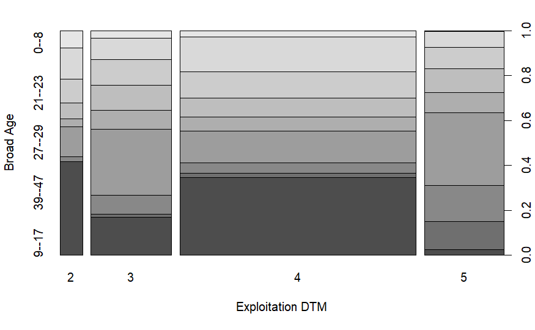

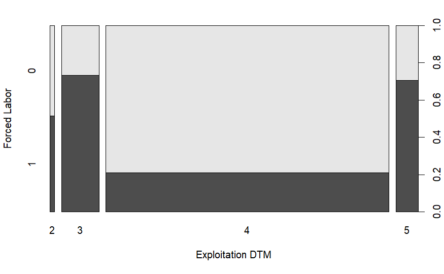

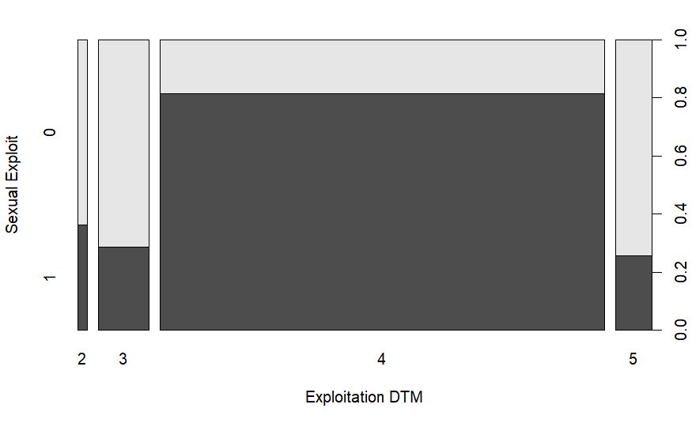

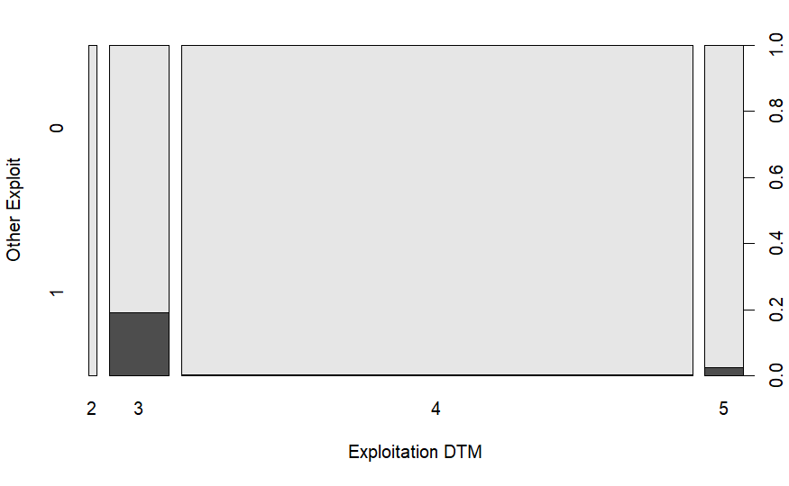

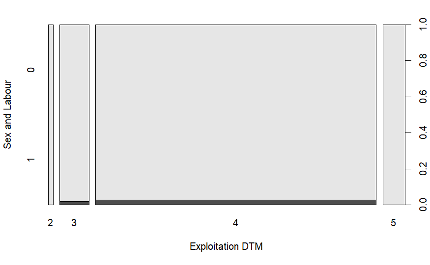

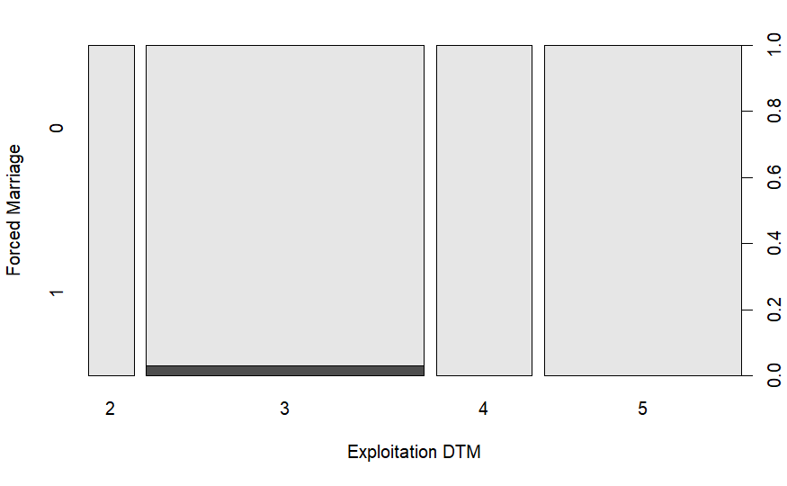

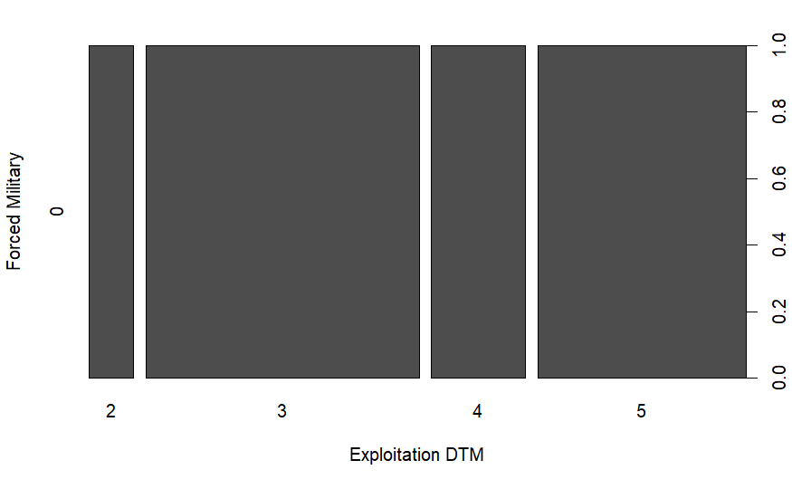

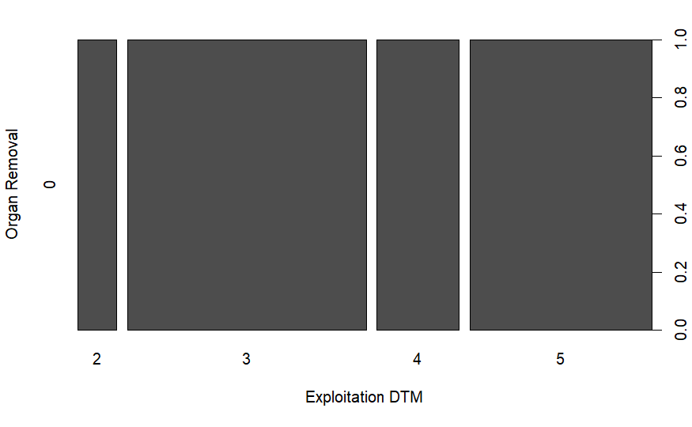

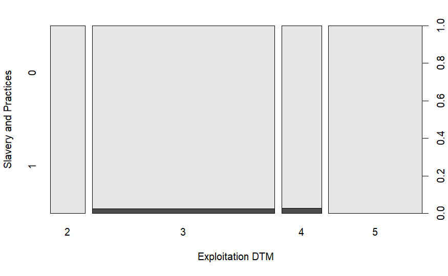

Exploitation DTM interacts strongest with Gender, Broad Age, Forced Labor, and Sexual Exploit. Again, there are no instances of Organ Removal or Forced military in the data set for entries in which the Exploitation DTM is known. And there is weak interaction with Other Exploit, Sex & Labour, Forced Marriage, and Slavery & practices

## Correlation between all Variables

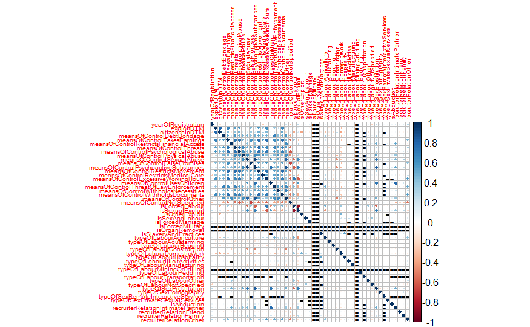

```r
library(corrplot)
corrplot(cor(traffic[-c(2:5,7)],  use = "pairwise.complete.obs"), method = "circle", tl.cex = 0.5, na.label = "-")
```

# Data Modification

## Dummy Variable Creation

Before creating a more advanced model for specific stages, it would be beneficial to make a model that classifies based on high or low DTM stages.

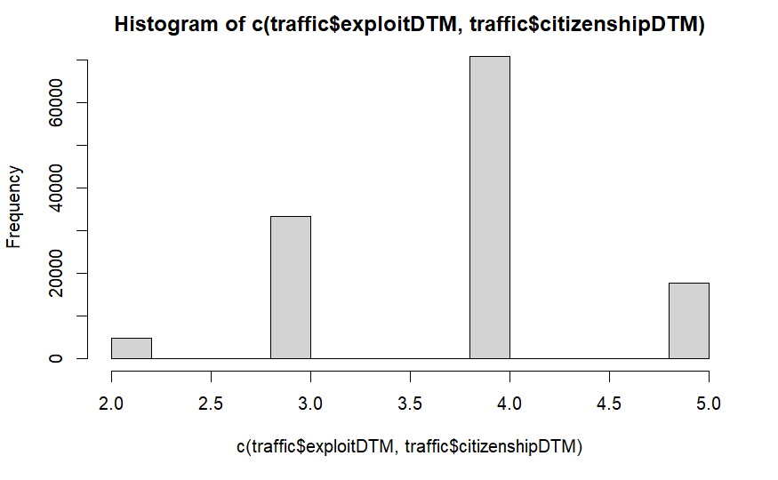

```r
hist(c(traffic$exploitDTM, traffic$citizenshipDTM))
```

We will classify all 4 and 5 stages as”high” and stages 2 and 3 as “low.” A dummy variable will be created with 1 for high stages, and 0 for low stages.

```r
traffic$CitHigh = ifelse(traffic$citizenshipDTM %in% c(2,3), 0,
                         ifelse(traffic$citizenshipDTM %in% c(4,5),1, NA))
traffic$ExploitHigh = ifelse(traffic$exploitDTM %in% c(2,3), 0,
                             ifelse(traffic$exploitDTM %in% c(4,5),1, NA))
```

```r
table(traffic$CitHigh)
```

```
    0     1
26392 26898
```

Our dataset contains 26898 high stage countries and 26392 low-stage countries for citizenship of victims

```r
table(traffic$ExploitHigh)
```

```
    0     1
11795 61697
```

Our dataset contains 61697 high stage countries and 11795 low-stage countries for where exploits occur

## Visualize missing values

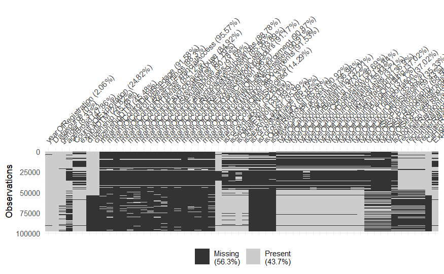

```r
library(naniar)
vis_miss(traffic, warn_large_data = FALSE)
```

From this it seems as though “meansOfControl-”, isForcedMarriage, isForcedMilitary, isOrganRemoval, and SlaveryAndPractices have the most missing values in our dataset. After removing them we can retry creating our model on this reduced dataset.

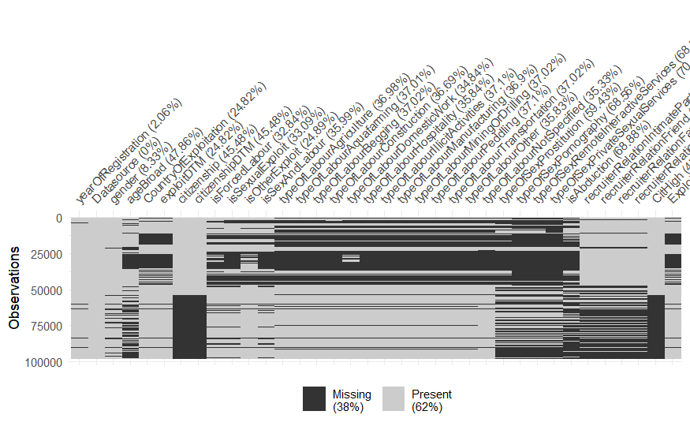

At this point it is hard to tell if any individual variables are contributing to missingness with this visual. So now we can use a bar-graph to get a count of the total number of missing values for each predictor.

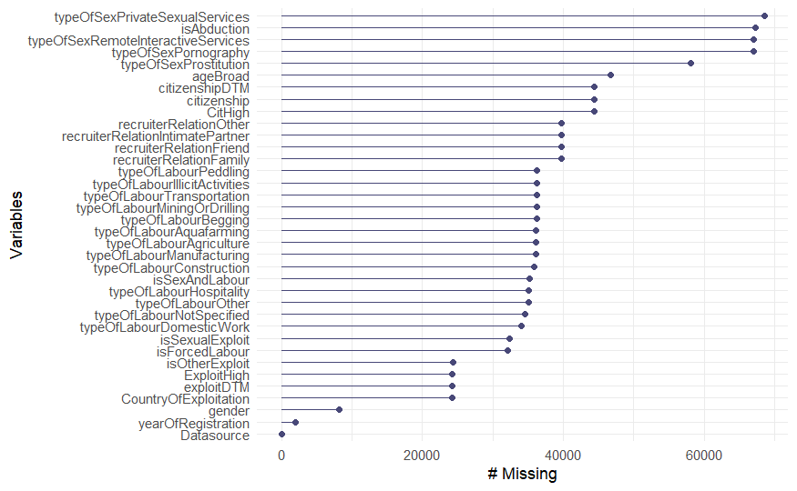

This shows us that typeOfSexPrivateSexualServices, isAbduction, typeOfSexRemoteInteractiveServices, typeOfSexPornography, and typeOfSexProstitution are our most missing values. Since a majority of these are “typeOfSex…” it may be helpful to see if these variables are missing at the same time or if their missingness is independent of each other.

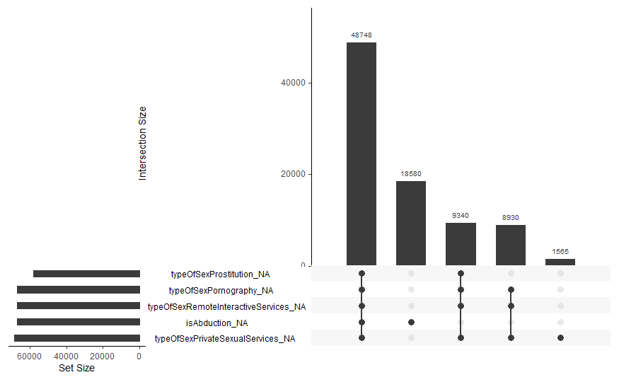

```r
gg_miss_upset(traffic2)
```

This visual shows that there is indeed an interaction between all 5 of these variables, there are 48748 observations in which all 5 of these variables are missing. So it would be beneficial to remove these variables from our dataset.

```r
traffic3 = traffic2[-c(26:30)]
sum(complete.cases(traffic2))
```

```
[1] 1428
```

```r
sum(complete.cases(traffic3))
```

```
[1] 7740
```

We have managed to go from having only 1428 complete cases to having 7740 complete cases after removing these 5 variables. This should be enough to create a preliminary model.

## Preprocess Data for Model Creation

Create a general model for stage of Exploitation country being high with all variables except yearOfRegistration, and DataSource (these things aren’t able to help law enforcement because if this information is known then victim is already found). Also remove Country names, and DTM stages since we have dummy variables representing these instead. Finally, we have removed any incomplete observations.

```r
sums = apply(traffic4[-c(1,2)], 2, sum)
sums[sums == 0 | sums == 1]
```

```
typeOfLabourIllicitActivities  typeOfLabourMiningOrDrilling    typeOfLabourTransportation
                            0                             0                             0
```

There are three variables in our complete dataset with 0 observed instances are typeOfLabourIllicitActivities, typeOfLabourMiningOrDrilling, and typeOfLabourTransportation, so we will remove these from the dataset.

|  | gender | ageBroad | exploitDTM | citizenshipDTM | isForcedLabour | isSexualExploit | isOtherExploit | isSexAndLabour | typeOfLabourAgriculture | typeOfLabourAquafarming | typeOfLabourBegging | typeOfLabourConstruction | typeOfLabourDomesticWork | typeOfLabourHospitality | typeOfLabourManufacturing | typeOfLabourPeddling | typeOfLabourOther | typeOfLabourNotSpecified | recruiterRelationIntimatePartner | recruiterRelationFriend | recruiterRelationFamily | recruiterRelationOther | CitHigh | ExploitHigh |
| --- | --- | --- | --- | --- | --- | --- | --- | --- | --- | --- | --- | --- | --- | --- | --- | --- | --- | --- | --- | --- | --- | --- | --- | --- |
| 3 | Male | 9--17 | 2 | 2 | 1 | 0 | 0 | 0 | 0 | 0 | 0 | 1 | 0 | 0 | 0 | 0 | 0 | 0 | 0 | 0 | 0 | 0 | 0 | 0 |
| 5 | Male | 9--17 | 3 | 2 | 1 | 0 | 0 | 0 | 0 | 0 | 0 | 0 | 0 | 0 | 0 | 1 | 0 | 0 | 0 | 0 | 0 | 0 | 0 | 0 |
| 6 | Male | 9--17 | 2 | 2 | 1 | 0 | 0 | 0 | 0 | 0 | 0 | 1 | 0 | 0 | 0 | 0 | 0 | 0 | 0 | 0 | 0 | 0 | 0 | 0 |
| 13 | Male | 9--17 | 2 | 2 | 1 | 0 | 0 | 0 | 0 | 0 | 0 | 1 | 0 | 0 | 0 | 0 | 0 | 0 | 0 | 0 | 0 | 0 | 0 | 0 |
| 16 | Male | 9--17 | 2 | 2 | 1 | 0 | 0 | 0 | 0 | 0 | 1 | 0 | 0 | 0 | 0 | 0 | 0 | 0 | 0 | 0 | 0 | 0 | 0 | 0 |
| 22 | Male | 9--17 | 2 | 2 | 1 | 0 | 0 | 0 | 0 | 0 | 1 | 0 | 0 | 0 | 0 | 0 | 0 | 0 | 0 | 0 | 0 | 0 | 0 | 0 |

## Analyze Dataset

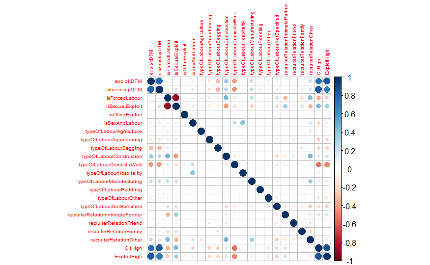

```r
library(corrplot)
corrplot(cor(traffic5[-c(1,2)],  use = "pairwise.complete.obs"), method = "circle", tl.cex = 0.5, na.label = "-")
```

# Simple Logit Model

```r
ExpMod1 = glm(ExploitHigh~factor(gender)+factor(ageBroad)+.-ageBroad-gender,
                    data = traffic5[-c(3,4,23)], family = binomial)
                    #3,4 are DTM stages and 23 is CitHigh

summary(ExpMod1)
```

```
Call:
glm(formula = ExploitHigh ~ factor(gender) + factor(ageBroad) +
    . - ageBroad - gender, family = binomial, data = traffic5[-c(3,
    4, 23)])

Deviance Residuals:
    Min       1Q   Median       3Q      Max
-3.1342   0.0000   0.1644   0.3439   3.9549

Coefficients:
                                  Estimate Std. Error z value Pr(>|z|)
(Intercept)                        -6.3965     0.5190 -12.326  < 2e-16 ***
factor(gender)Male                  0.9795     0.1954   5.012 5.39e-07 ***
factor(ageBroad)18--20              4.5066     0.4741   9.506  < 2e-16 ***
factor(ageBroad)21--23              4.0495     0.4665   8.680  < 2e-16 ***
factor(ageBroad)24--26              4.5699     0.4782   9.556  < 2e-16 ***
factor(ageBroad)27--29              5.6086     0.5247  10.690  < 2e-16 ***
factor(ageBroad)30--38              4.8094     0.4635  10.377  < 2e-16 ***
factor(ageBroad)39--47              6.0304     0.4954  12.172  < 2e-16 ***
factor(ageBroad)48+                21.5926   469.1908   0.046   0.9633
factor(ageBroad)9--17               2.2605     0.4507   5.016 5.29e-07 ***
isForcedLabour                      3.4065     0.2984  11.416  < 2e-16 ***
isSexualExploit                     4.6880     0.2365  19.823  < 2e-16 ***
isOtherExploit                    -23.0987  2615.2451  -0.009   0.9930
isSexAndLabour                     -5.3142     0.4287 -12.395  < 2e-16 ***
typeOfLabourAgriculture            15.0037  1013.6828   0.015   0.9882
typeOfLabourAquafarming           -23.6878   842.9367  -0.028   0.9776
typeOfLabourBegging               -20.1704   894.6366  -0.023   0.9820
typeOfLabourConstruction           -1.7618     0.2443  -7.212 5.52e-13 ***
typeOfLabourDomesticWork           -5.5542     0.2857 -19.443  < 2e-16 ***
typeOfLabourHospitality            -1.6385     0.3472  -4.719 2.37e-06 ***
typeOfLabourManufacturing          15.1500   469.7002   0.032   0.9743
typeOfLabourPeddling              -19.8161  2874.1309  -0.007   0.9945
typeOfLabourOther                  -3.7171     0.5535  -6.716 1.87e-11 ***
typeOfLabourNotSpecified           -1.3467     0.1389  -9.694  < 2e-16 ***
recruiterRelationIntimatePartner   17.3621   355.0364   0.049   0.9610
recruiterRelationFriend             0.5825     0.1856   3.139   0.0017 **
recruiterRelationFamily             2.8108     0.3199   8.785  < 2e-16 ***
recruiterRelationOther              1.9978     0.2001   9.986  < 2e-16 ***
---
Signif. codes:  0 ‘***’ 0.001 ‘**’ 0.01 ‘*’ 0.05 ‘.’ 0.1 ‘ ’ 1

(Dispersion parameter for binomial family taken to be 1)

    Null deviance: 8750.8  on 7739  degrees of freedom
Residual deviance: 3195.2  on 7712  degrees of freedom
AIC: 3251.2

Number of Fisher Scoring iterations: 18
```

### Train/Test model for exploit DTM

Create a dataset of complete enteries only

```r
set.seed(122) #set seed to ensure same sample each time
# Shuffle Data To Ensure Random Sampling

shuffle = traffic5[sample(1:nrow(traffic5)),]

index = ceiling(nrow(traffic5)*0.9) # 0.9 = 90% training data split
train = shuffle[c(1:index),][-c(3,4)]
test = shuffle[c((index+1):nrow(shuffle)),]
```

First we will train the model on our training data:

```r
ExpDTMMod1 = glm(ExploitHigh~factor(gender)+factor(ageBroad)+., data = train[-c(21)], family = binomial)
#summary(ExpDTMMod1)
```

Now we will predict the probabilities on our test data:

```r
ExpPredictions = predict(ExpDTMMod1, test, type="response")
```

Since our Variable ExploitHigh already uses values 0 and 1, and probabilities go from 0 to 1, we can simply find the difference between the prediction vector, and the ExploitHigh vector to get an idea of how accurate our model was.

```r
mean(abs(ExpPredictions - test$ExploitHigh))
```

```
[1] 0.111528
```

Our model has an average distance from the correct value of .112.

For each predicted probability, we want to round high values to 1 to classify the observation as HighDtm, and 0 for lower probabilities. For now we will use 0.5 as a midpoint and round up or down accordingly.

```r
ExpPredClass = ifelse(ExpPredictions<0.5,0,1)
```

Then by finding the difference, this gives us a 1 every time there is a misclassification, and a 0 if classified correctly. By summing this new vector of absolute differences, we get the total number of misclassifications:

```r
sum(abs(ExpPredClass - test$ExploitHigh))
```

```
[1] 40
```

Our model had a total of 40 misclassifications on the test data.

```r
40/nrow(test)
```

```
[1] 0.05167959
```

This comes out to an error rate of 5.1%

### Analyzing Errors

Create table with DTM stage, DTM high, and prediction, and if prediction is correct

```r
act.pred = data.frame(DTM = test$exploitDTM,
                      High = test$ExploitHigh,
                      Prediction = ExpPredClass,
                      Correct = 1 - abs(ExpPredClass - test$ExploitHigh))
row.names(act.pred) <- NULL
act.pred
```

| DTM | High | Prediction | Correct |
| --- | --- | --- | --- |
| 5 | 1 | 1 | 1 |
| 4 | 1 | 1 | 1 |
| 4 | 1 | 1 | 1 |
| 4 | 1 | 0 | 0 |
| 4 | 1 | 1 | 1 |
| 5 | 1 | 1 | 1 |
| 5 | 1 | 1 | 1 |
| 4 | 1 | 1 | 1 |
| 4 | 1 | 1 | 1 |
| 5 | 1 | 1 | 1 |

[output cut: 764 more lines]

Create a contengiencey table to see where misclassifications are:

```r
table(act.pred$High, act.pred$Correct, dnn=c("High DTM", "Correct"))
```

```
        Correct
High DTM   0   1
       0  28 146
       1  12 588
```

From the table, it seems like a disproportionate amount of misclassifications came from Low DTM countries being classified into High-DTM countries. However, the model is still fairly accurate.

```r
table(act.pred$DTM, act.pred$Correct, dnn=c("DTM", "Correct"))
```

```
   Correct
DTM   0   1
  2   1  23
  3  27 123
  4   8 257
  5   4 331
```

However, it seems like the most misclassifications occurred in our mid-range DTM stages, and that very few misclassifications happened in Stage 2 countries and Stage 5 countries. Perhaps modifying our model to classify into 4 classes would be better. but to do this, we need a greater number of complete observations. As a result, we would have to remove more predictors, which could sacrifice the efficacy or validity of our model.

To help improve this, simply changing our rounding cutoff may yield better outcomes.

### Determining Rounding Cutoff

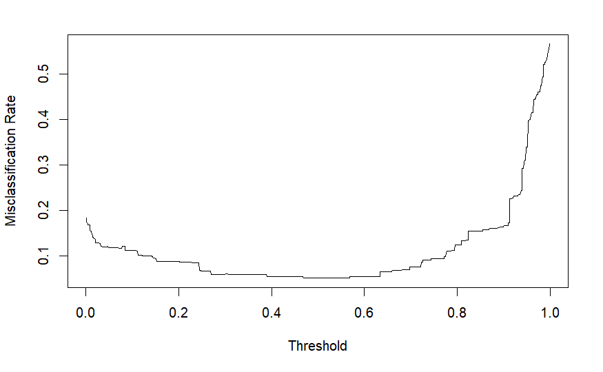

```r
predprob = predict(ExpMod1, test, type = "response")

thresh <- seq(0.001,0.999,0.001)
err = as.numeric(seq(1,length(thresh)))

  for(j in seq(along=thresh)){
    pp = ifelse(ExpPredictions<thresh[j],0,1)
    xx = sum(abs(pp - test$ExploitHigh))
    paste(xx)
    error = xx/nrow(test)
    err[j] <- error
}


matplot(thresh,err,type="l",xlab="Threshold" ,ylab="Misclassification Rate",lty=1:2)
```

*** Try Bootstrapping, and apply some sort of “weight” of which complete observations to select based off of occurrence of binary labels in full data set with missing values complete ***

- Randomly select complete observation
- append it to dataset with weight of the norm (l1, or l2) of the difference between each observed value and the difference from the mean value in the full dataset.

*** Try dropout each iteration? ***

*** Replace missing values with mean of value for rest of dataset ***

*** Replace missing values with mean of value for rest of dataset entries in which similar variables are known *** - If isSexualExploit is unknown, but we know the type of labor was prostitution, what is the mean value for isSexualExploit for observations that also have prostition, and use that as replacement